# Practical Machine Learning Project

Henrique dos Santos Almeida

23 de setembro de 2018

## Summary

### Background

Using devices such as Jawbone Up, Nike FuelBand, and Fitbit it is now possible to collect a large amount of data about personal activity relatively inexpensively. These type of devices are part of the quantified self movement - a group of enthusiasts who take measurements about themselves regularly to improve their health, to find patterns in their behavior, or because they are tech geeks. One thing that people regularly do is quantify how much of a particular activity they do, but they rarely quantify how well they do it. The goal of this project is to use data from accelerometers on the belt, forearm, arm, and dumbbell of 6 participants as they perform barbell lifts correctly and incorrectly 5 different ways.

Six young healthy participants were asked to perform one set of 10 repetitions of the Unilateral Dumbbell Biceps Curl in five different fashions: * Class A - exactly according to the specification * Class B - throwing the elbows to the front * Class C - lifting the dumbbell only halfway * Class D - lowering the dumbbell only halfway * Class E - throwing the hips to the front

Class A corresponds to the specified execution of the exercise, while the other 4 classes correspond to common mistakes.

### Data

The training data for this project are available at:

https://d396qusza40orc.cloudfront.net/predmachlearn/pml-training.csv

The test data are available at:

https://d396qusza40orc.cloudfront.net/predmachlearn/pml-testing.csv

### Objective

The goal of this project is to predict the manner in which subjects did the exercise. This is the “classe” variable in the training set. The model will use the other variables to predict it.

## Geting and cleaning data

### Geting data

```r
## Packages ##
library(caret)
library(randomForest)
```

```r
library(rpart)
library(rpart.plot)
#### Geting and reading data ####
# setwd("Documentos/coursera/pratical_machining/project/")
download.file(url = "https://d396qusza40orc.cloudfront.net/predmachlearn/pml-training.csv",
               destfile = "training.csv")
 download.file(url = "https://d396qusza40orc.cloudfront.net/predmachlearn/pml-testing.csv",
               destfile = "testing.csv")
```

### Visualizing data

```r
#### Visualizing data ####
training <- read.csv(file="training.csv")
testing <- read.csv(file="testing.csv")
## Print first 25 columns ##
str(training[,1:25])
```

```
## 'data.frame':    19622 obs. of  25 variables:
##  $ X                   : int  1 2 3 4 5 6 7 8 9 10 ...
##  $ user_name           : Factor w/ 6 levels "adelmo","carlitos",..: 2 2 2 2 2 2 2 2 2 2 ...
##  $ raw_timestamp_part_1: int  1323084231 1323084231 1323084231 1323084232 1323084232 1323084232 1323084232 1323084232 1323084232 1323084232 ...
##  $ raw_timestamp_part_2: int  788290 808298 820366 120339 196328 304277 368296 440390 484323 484434 ...
##  $ cvtd_timestamp      : Factor w/ 20 levels "02/12/2011 13:32",..: 9 9 9 9 9 9 9 9 9 9 ...
##  $ new_window          : Factor w/ 2 levels "no","yes": 1 1 1 1 1 1 1 1 1 1 ...
##  $ num_window          : int  11 11 11 12 12 12 12 12 12 12 ...
##  $ roll_belt           : num  1.41 1.41 1.42 1.48 1.48 1.45 1.42 1.42 1.43 1.45 ...
##  $ pitch_belt          : num  8.07 8.07 8.07 8.05 8.07 8.06 8.09 8.13 8.16 8.17 ...
##  $ yaw_belt            : num  -94.4 -94.4 -94.4 -94.4 -94.4 -94.4 -94.4 -94.4 -94.4 -94.4 ...
##  $ total_accel_belt    : int  3 3 3 3 3 3 3 3 3 3 ...
##  $ kurtosis_roll_belt  : Factor w/ 397 levels "","0.000673",..: 1 1 1 1 1 1 1 1 1 1 ...
##  $ kurtosis_picth_belt : Factor w/ 317 levels "","0.006078",..: 1 1 1 1 1 1 1 1 1 1 ...
##  $ kurtosis_yaw_belt   : Factor w/ 2 levels "","#DIV/0!": 1 1 1 1 1 1 1 1 1 1 ...
##  $ skewness_roll_belt  : Factor w/ 395 levels "","0.000000",..: 1 1 1 1 1 1 1 1 1 1 ...
##  $ skewness_roll_belt.1: Factor w/ 338 levels "","0.000000",..: 1 1 1 1 1 1 1 1 1 1 ...
##  $ skewness_yaw_belt   : Factor w/ 2 levels "","#DIV/0!": 1 1 1 1 1 1 1 1 1 1 ...
##  $ max_roll_belt       : num  NA NA NA NA NA NA NA NA NA NA ...
##  $ max_picth_belt      : int  NA NA NA NA NA NA NA NA NA NA ...
##  $ max_yaw_belt        : Factor w/ 68 levels "","0.0","-0.1",..: 1 1 1 1 1 1 1 1 1 1 ...
##  $ min_roll_belt       : num  NA NA NA NA NA NA NA NA NA NA ...
##  $ min_pitch_belt      : int  NA NA NA NA NA NA NA NA NA NA ...
##  $ min_yaw_belt        : Factor w/ 68 levels "","0.0","-0.1",..: 1 1 1 1 1 1 1 1 1 1 ...
##  $ amplitude_roll_belt : num  NA NA NA NA NA NA NA NA NA NA ...
##  $ amplitude_pitch_belt: int  NA NA NA NA NA NA NA NA NA NA ...
```

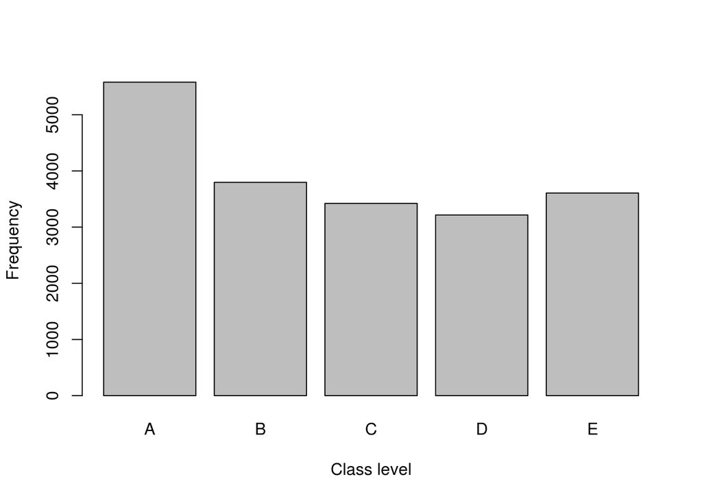

```r
## Check classes ##
plot(training$classe,xlab="Class level",ylab="Frequency")
```

### Cleaning Data

There are some columns that should be removed from data (columns 1 to 7) and others that have empty values or values equal to 0 or “NA”. Those columns will be removed from data.

```r
#### Cleaning Data ####
# Removing unecessary fields #
training <- training[,c(-1:-7)]
testing <- testing[,c(-1:-7)]
# Sum NA and ""
get_empty <- function(df=training){
  total_empty <- numeric()
  for(i in 1:ncol(df)){
    total_empty[i] <- sum(is.na(as.character(df[,i])))+sum(length(which(nchar(as.character(df[,i])) == 0)))
  }
  return(total_empty)
}
total_empty <- get_empty(df=training)
# Removing all columns that have NA's
training <- training[,which(total_empty==0)]
```

## Model Development

The main objective of the model will be predict what kind of classe (A to E) the observations from the testing data are based on all atributes observed. For this kind of problem two models will be tested: decision trees and random forest. A cross validation will be made first with the training dataset in order to verify which model has higher accuracy and if that accuracy is high.

### Cross Validation

#### Dividing training dataset

To reproduce this the seed must be set 12233. The main objective of this process is to divide the training in two random samples (train1 and train2). One of them will represent 90% of the entire data set and the other will be used to predict classes using the model choosed and them compared with the real class in order to obsverve the accuracy and other atributes of the models

```r
#### Creating Model ####
set.seed(12233)

## Dividing training dataset in 2 parts with p=0.9
inTrain <- createDataPartition(training$classe, p = 0.9, list=FALSE)
train1 <- training[inTrain,]
train2 <- training[-inTrain,]
```

## Expected out-of-sample error

The expected out-of-sample error must be as lower as possible and correspond to 1 - accuracy. First models will be tested in the train2 data set and the one that have higher accuracy (or lower out-of-sample error) will be choosed to predict classes of the testing data.

### Testing Model Decision Tree

```r
decisionModel <- rpart(classe~., data=train1, method="class")
decisionModel
```

```
## n= 17662
##
## node), split, n, loss, yval, (yprob)
##       * denotes terminal node
##
##     1) root 17662 12640 A (0.28 0.19 0.17 0.16 0.18)
##       2) roll_belt< 130.5 16187 11179 A (0.31 0.21 0.19 0.18 0.11)
##         4) pitch_forearm< -33.95 1428    10 A (0.99 0.007 0 0 0) *
##         5) pitch_forearm>=-33.95 14759 11169 A (0.24 0.23 0.21 0.2 0.12)
##          10) magnet_dumbbell_y< 439.5 12468  8953 A (0.28 0.18 0.24 0.19 0.11)
##            20) roll_forearm< 123.5 7739  4596 A (0.41 0.18 0.18 0.17 0.061)
##              40) magnet_dumbbell_z< -27.5 2613   868 A (0.67 0.21 0.012 0.077 0.029)
##                80) roll_forearm>=-136.5 2186   484 A (0.78 0.18 0.012 0.026 0.0064) *
##                81) roll_forearm< -136.5 427   255 B (0.1 0.4 0.012 0.34 0.15) *
##              41) magnet_dumbbell_z>=-27.5 5126  3728 A (0.27 0.17 0.27 0.21 0.077)
##                82) yaw_belt>=168.5 674   102 A (0.85 0.082 0.0015 0.064 0.0045) *
##                83) yaw_belt< 168.5 4452  3057 C (0.19 0.18 0.31 0.23 0.088)
##                 166) accel_dumbbell_y>=-40.5 3843  2817 D (0.21 0.2 0.22 0.27 0.094)
##                   332) pitch_belt< -43.15 415    57 B (0.012 0.86 0.077 0.029 0.019) *
##                   333) pitch_belt>=-43.15 3428  2414 D (0.24 0.12 0.24 0.3 0.1)
##                     666) roll_belt>=125.5 829   345 C (0.37 0.035 0.58 0.011 0.0036)
##                      1332) magnet_belt_z< -322.5 267    11 A (0.96 0.0037 0.026 0 0.011) *
##                      1333) magnet_belt_z>=-322.5 562    85 C (0.085 0.05 0.85 0.016 0) *
##                     667) roll_belt< 125.5 2599  1594 D (0.2 0.15 0.13 0.39 0.14)
##                      1334) pitch_belt>=1.305 1652  1261 A (0.24 0.21 0.14 0.22 0.19)
##                        2668) accel_dumbbell_z< 27.5 1060   693 A (0.35 0.13 0.21 0.27 0.037)
##                          5336) yaw_forearm>=-94.65 756   389 A (0.49 0.18 0.22 0.075 0.038)
##                           10672) magnet_forearm_z>=-137.5 505   145 A (0.71 0.13 0.018 0.1 0.036) *
##                           10673) magnet_forearm_z< -137.5 251    91 C (0.028 0.27 0.64 0.024 0.044) *
##                          5337) yaw_forearm< -94.65 304    70 D (0 0.03 0.17 0.77 0.033) *
##                        2669) accel_dumbbell_z>=27.5 592   316 E (0.041 0.35 0.012 0.13 0.47)
##                          5338) roll_dumbbell< 38.61985 210    52 B (0.043 0.75 0.033 0.048 0.12) *
##                          5339) roll_dumbbell>=38.61985 382   132 E (0.039 0.13 0 0.18 0.65) *
##                      1335) pitch_belt< 1.305 947   311 D (0.13 0.038 0.13 0.67 0.038) *
##                 167) accel_dumbbell_y< -40.5 609    76 C (0.0099 0.038 0.88 0.031 0.046) *
##            21) roll_forearm>=123.5 4729  3173 C (0.079 0.18 0.33 0.23 0.19)
##              42) magnet_dumbbell_y< 291.5 2772  1442 C (0.094 0.13 0.48 0.15 0.15)
##                84) magnet_forearm_z< -251 224    46 A (0.79 0.071 0 0.045 0.089) *
##                85) magnet_forearm_z>=-251 2548  1218 C (0.033 0.14 0.52 0.16 0.15)
##                 170) pitch_belt>=26.15 174    35 B (0.092 0.8 0.023 0 0.086) *
##                 171) pitch_belt< 26.15 2374  1048 C (0.028 0.089 0.56 0.17 0.16) *
##              43) magnet_dumbbell_y>=291.5 1957  1276 D (0.057 0.24 0.12 0.35 0.24)
##                86) accel_forearm_x>=-101.5 1252   832 E (0.054 0.3 0.16 0.15 0.34)
##                 172) magnet_arm_y>=188.5 510   233 B (0.016 0.54 0.23 0.11 0.1) *
##                 173) magnet_arm_y< 188.5 742   374 E (0.08 0.14 0.11 0.18 0.5) *
##                87) accel_forearm_x< -101.5 705   211 D (0.062 0.12 0.037 0.7 0.075) *
##          11) magnet_dumbbell_y>=439.5 2291  1125 B (0.033 0.51 0.042 0.22 0.19)
##            22) total_accel_dumbbell>=5.5 1636   575 B (0.046 0.65 0.057 0.021 0.23)
##              44) roll_belt>=-0.59 1384   323 B (0.054 0.77 0.068 0.025 0.087) *
##              45) roll_belt< -0.59 252     0 E (0 0 0 0 1) *
##            23) total_accel_dumbbell< 5.5 655   175 D (0 0.16 0.0031 0.73 0.1) *
##       3) roll_belt>=130.5 1475    14 E (0.0095 0 0 0 0.99) *
```

```r
#### Testing Model ###
## Testing the model with train2 data from training dataset
train2_pred <- predict(decisionModel, newdata=train2,type = "class")
## Test result in train2 data ##
## Confusion Matrix
confusionMatrix(reference = train2_pred,data = train2$classe)
```

```
## Confusion Matrix and Statistics
##
##           Reference
## Prediction   A   B   C   D   E
##          A 499  18  11  25   5
##          B  51 232  50  23  23
##          C   7  29 279  21   6
##          D  25  20  46 210  20
##          E   7  38  36  17 262
##
## Overall Statistics
##
##                Accuracy : 0.7561
##                  95% CI : (0.7365, 0.775)
##     No Information Rate : 0.3005
##     P-Value [Acc > NIR] : < 2.2e-16
##
##                   Kappa : 0.691
##  Mcnemar's Test P-Value : 1.081e-08
##
## Statistics by Class:
##
##                      Class: A Class: B Class: C Class: D Class: E
## Sensitivity            0.8472   0.6884   0.6611   0.7095   0.8291
## Specificity            0.9570   0.9094   0.9590   0.9333   0.9404
## Pos Pred Value         0.8943   0.6121   0.8158   0.6542   0.7278
## Neg Pred Value         0.9358   0.9336   0.9116   0.9475   0.9663
## Prevalence             0.3005   0.1719   0.2153   0.1510   0.1612
## Detection Rate         0.2546   0.1184   0.1423   0.1071   0.1337
## Detection Prevalence   0.2847   0.1934   0.1745   0.1638   0.1837
## Balanced Accuracy      0.9021   0.7989   0.8101   0.8214   0.8848
```

From results above we can observe that this model has a accuracy of 75.61% so we can expect an out-sample-error of 24.39% .

### Testing Model Random Forest

```r
randomForMod <- randomForest(classe~., data=train1, importance=TRUE)
randomForMod
```

```
##
## Call:
##  randomForest(formula = classe ~ ., data = train1, importance = TRUE)
##                Type of random forest: classification
##                      Number of trees: 500
## No. of variables tried at each split: 7
##
##         OOB estimate of  error rate: 0.33%
## Confusion matrix:
##      A    B    C    D    E  class.error
## A 5020    2    0    0    0 0.0003982477
## B   11 3405    2    0    0 0.0038033938
## C    0   13 3066    1    0 0.0045454545
## D    0    0   24 2869    2 0.0089810017
## E    0    0    1    2 3244 0.0009239298
```

```r
#### Testing Model ###
## Testing the model with train2 data from training dataset
train2_pred <- predict(randomForMod, newdata=train2)
## Confusion Matrix
confusionMatrix(train2_pred, train2$classe)
```

```
## Confusion Matrix and Statistics
##
##           Reference
## Prediction   A   B   C   D   E
##          A 557   1   0   0   0
##          B   1 378   0   0   0
##          C   0   0 342   3   2
##          D   0   0   0 318   0
##          E   0   0   0   0 358
##
## Overall Statistics
##
##                Accuracy : 0.9964
##                  95% CI : (0.9927, 0.9986)
##     No Information Rate : 0.2847
##     P-Value [Acc > NIR] : < 2.2e-16
##
##                   Kappa : 0.9955
##  Mcnemar's Test P-Value : NA
##
## Statistics by Class:
##
##                      Class: A Class: B Class: C Class: D Class: E
## Sensitivity            0.9982   0.9974   1.0000   0.9907   0.9944
## Specificity            0.9993   0.9994   0.9969   1.0000   1.0000
## Pos Pred Value         0.9982   0.9974   0.9856   1.0000   1.0000
## Neg Pred Value         0.9993   0.9994   1.0000   0.9982   0.9988
## Prevalence             0.2847   0.1934   0.1745   0.1638   0.1837
## Detection Rate         0.2842   0.1929   0.1745   0.1622   0.1827
## Detection Prevalence   0.2847   0.1934   0.1770   0.1622   0.1827
## Balanced Accuracy      0.9987   0.9984   0.9985   0.9953   0.9972
```

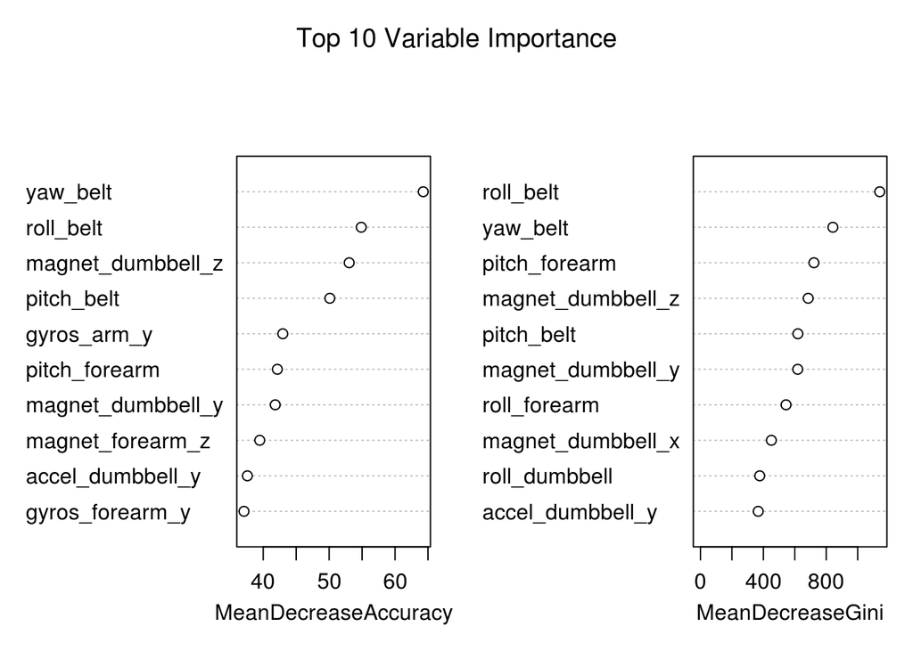

```r
randomImp <- varImp(randomForMod, scale=FALSE)
varImpPlot(randomForMod,sort = TRUE, n.var = 10, main="Top 10 Variable Importance")
```

```r
testing_pred <- predict(randomForMod, newdata=testing)
#testing_pred
testing$class <- testing_pred
## Save Result ##
write.csv(x=testing,file = "testing_class.csv")
```

## Results

```r
## Print Result ##
as.character(testing$class)
```

```
##  [1] "B" "A" "B" "A" "A" "E" "D" "B" "A" "A" "B" "C" "B" "A" "E" "E" "A"
## [18] "B" "B" "B"
```